# COMPSCIX 415.2 Homework 5/Midterm

Kritika Jain

3/3/2019

```r
library(dplyr)
library(tidyverse)
library(ggplot2)
library(tibble)
```

## Midterm for Intro to Data Science

#### Table of Contents

1. The Tidyverse Packages
2. R Basics
3. Data Import/Export
4. Visualization
5. Data Munging and Wrangling
6. EDA
7. Git and Github

### 2. R Basics

1. Fix this code with the fewest number of changes so it still works:

Old code: My_data.name___is.too00ooLong! <- c( 1 , 2 , 3 )

New code: My_data.name___is.too00ooLong <- c( 1 , 2 , 3 ) *(just remove the ‘!’)*

2. Fix this code so it works.

Old code: my_string <- C(‘has’, ‘an’, ‘error’, ‘in’, ’it)

New code: my_string <- c(‘has’, ‘an’, ‘error’, ‘in’, ‘it’) *(lowercase ‘c’ add an end quote after it)*

### 3. Data Import/Export

Below is the code to import the file “rail_trail.txt” and take a glimpse of it. Then export it under the name “rail_trail.csv” with it being comma-separated. Import it once again and take a glimpse.

```r
file_path <- "/users/kritika.jain/downloads/rail_trail.txt"
text_data <- read_delim(file = file_path, delim = "|")
glimpse(text_data)
```

```
## Observations: 90
## Variables: 10
## $ hightemp   <dbl> 83, 73, 74, 95, 44, 69, 66, 66, 80, 79, 78, 65, 41, 5…
## $ lowtemp    <dbl> 50, 49, 52, 61, 52, 54, 39, 38, 55, 45, 55, 48, 49, 3…
## $ avgtemp    <dbl> 66.5, 61.0, 63.0, 78.0, 48.0, 61.5, 52.5, 52.0, 67.5,…
## $ spring     <dbl> 0, 0, 1, 0, 1, 1, 1, 1, 0, 0, 0, 1, 1, 0, 0, 1, 0, 1,…
## $ summer     <dbl> 1, 1, 0, 1, 0, 0, 0, 0, 1, 1, 1, 0, 0, 0, 0, 0, 1, 0,…
## $ fall       <dbl> 0, 0, 0, 0, 0, 0, 0, 0, 0, 0, 0, 0, 0, 1, 1, 0, 0, 0,…
## $ cloudcover <dbl> 7.6, 6.3, 7.5, 2.6, 10.0, 6.6, 2.4, 0.0, 3.8, 4.1, 8.…
## $ precip     <dbl> 0.00, 0.29, 0.32, 0.00, 0.14, 0.02, 0.00, 0.00, 0.00,…
## $ volume     <dbl> 501, 419, 397, 385, 200, 375, 417, 629, 533, 547, 432…
## $ weekday    <dbl> 1, 1, 1, 0, 1, 1, 1, 0, 0, 1, 1, 1, 1, 1, 1, 1, 0, 1,…
```

```r
write_csv(text_data, path="/users/kritika.jain/downloads/rail_trail.csv")
file_path2 <- "/users/kritika.jain/downloads/rail_trail.csv"
csv_data <- read_csv(file = file_path2)
glimpse(csv_data)
```

```
## Observations: 90
## Variables: 10
## $ hightemp   <dbl> 83, 73, 74, 95, 44, 69, 66, 66, 80, 79, 78, 65, 41, 5…
## $ lowtemp    <dbl> 50, 49, 52, 61, 52, 54, 39, 38, 55, 45, 55, 48, 49, 3…
## $ avgtemp    <dbl> 66.5, 61.0, 63.0, 78.0, 48.0, 61.5, 52.5, 52.0, 67.5,…
## $ spring     <dbl> 0, 0, 1, 0, 1, 1, 1, 1, 0, 0, 0, 1, 1, 0, 0, 1, 0, 1,…
## $ summer     <dbl> 1, 1, 0, 1, 0, 0, 0, 0, 1, 1, 1, 0, 0, 0, 0, 0, 1, 0,…
## $ fall       <dbl> 0, 0, 0, 0, 0, 0, 0, 0, 0, 0, 0, 0, 0, 1, 1, 0, 0, 0,…
## $ cloudcover <dbl> 7.6, 6.3, 7.5, 2.6, 10.0, 6.6, 2.4, 0.0, 3.8, 4.1, 8.…
## $ precip     <dbl> 0.00, 0.29, 0.32, 0.00, 0.14, 0.02, 0.00, 0.00, 0.00,…
## $ volume     <dbl> 501, 419, 397, 385, 200, 375, 417, 629, 533, 547, 432…
## $ weekday    <dbl> 1, 1, 1, 0, 1, 1, 1, 0, 0, 1, 1, 1, 1, 1, 1, 1, 0, 1,…
```

### 4. Visualization

1. There are many things wrong with the first infographic. Firstly, it says that this is a percentage of respondents, but the numbers in the graphic don’t add up to 100%. Secondly, the men and women respondents vs the age range respondents could have been represented in a different way. Lastly, the circles that are around the numbers are overwhelming to the eyes, instead if this was in a bar chart that would be more visually pleasing.

2. ```
   ggplot(data = diamonds, mapping = aes(x=cut, y=carat, color=color)) + geom_boxplot(aes(fill = color), position = "identity") + coord_flip() +labs(x = "CUT OF DIAMOND", y = "CARAT OF DIAMOND")
   ```

3. We can fix the coordinates on the “carat” axis to be a shorter range. This will help the analyist see the points on the boxplot a little better.

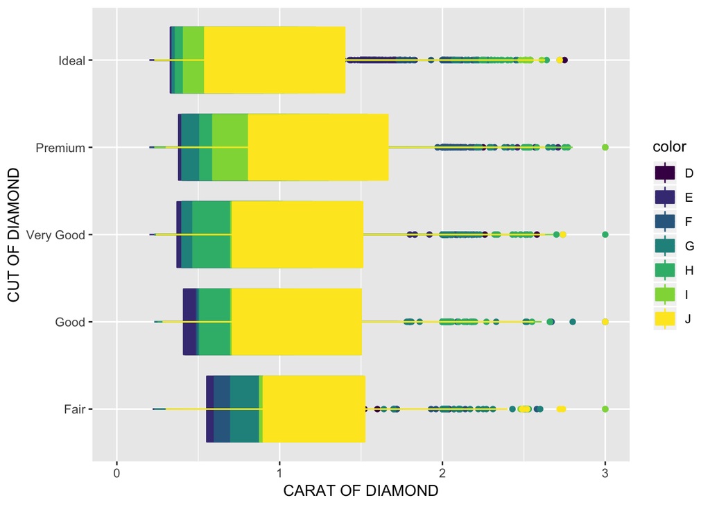

```r
ggplot(data = diamonds, mapping = aes(x=cut, y=carat, color=color)) + geom_boxplot(aes(fill = color), position = "identity") + coord_flip() +labs(x = "CUT OF DIAMOND", y = "CARAT OF DIAMOND") + ylim(0,3)
```

### 5. Data Munging and Wrangling

```r
head(table2)
```

```
## # A tibble: 6 x 4
##   country      year type           count
##   <chr>       <int> <chr>          <int>
## 1 Afghanistan  1999 cases            745
## 2 Afghanistan  1999 population  19987071
## 3 Afghanistan  2000 cases           2666
## 4 Afghanistan  2000 population  20595360
## 5 Brazil       1999 cases          37737
## 6 Brazil       1999 population 172006362
```

This table is NOT tidy. It has the same value for multiple rows for the same column. Instead, we can make cases and population column headers.

```r
spread(table2, key = type, value = count)
```

```
## # A tibble: 6 x 4
##   country      year  cases population
##   <chr>       <int>  <int>      <int>
## 1 Afghanistan  1999    745   19987071
## 2 Afghanistan  2000   2666   20595360
## 3 Brazil       1999  37737  172006362
## 4 Brazil       2000  80488  174504898
## 5 China        1999 212258 1272915272
## 6 China        2000 213766 1280428583
```

2. If we want to add a new column, we use the mutate() function. We need to use division to get the price per carat. We would mutate the old table and assign it to itself, overriding the old variable. This is what the code should look like.

diamonds <- mutate(diamonds, price_per_carat = price / carat)

```r
diamonds %>% mutate(max = price > 10000, min = carat < 1.5) %>% group_by(cut) %>% summarise(count = n(), num = sum(max & min), prop = (num / count) * 100)
```

```
## # A tibble: 5 x 4
##   cut       count   num  prop
##   <ord>     <int> <int> <dbl>
## 1 Fair       1610     4 0.248
## 2 Good       4906    17 0.347
## 3 Very Good 12082   155 1.28
## 4 Premium   13791   173 1.25
## 5 Ideal     21551   485 2.25
```

This tibble makes sense because of correlation. As the price increases, the carat size also increases. It is a little odd that even fair diamonds are priced so high. It seems like some are even priced the same as higher quality diamonds. It would be interesting to see why they are prices so highly.

### 6. EDA

1.From the summary below, we can see that the data set it from 2000 to 2015.

```r
summary(txhousing)
```

```
##      city                year          month            sales
##  Length:8602        Min.   :2000   Min.   : 1.000   Min.   :   6.0
##  Class :character   1st Qu.:2003   1st Qu.: 3.000   1st Qu.:  86.0
##  Mode  :character   Median :2007   Median : 6.000   Median : 169.0
##                     Mean   :2007   Mean   : 6.406   Mean   : 549.6
##                     3rd Qu.:2011   3rd Qu.: 9.000   3rd Qu.: 467.0
##                     Max.   :2015   Max.   :12.000   Max.   :8945.0
##                                                     NA's   :568
##      volume              median          listings       inventory
##  Min.   :8.350e+05   Min.   : 50000   Min.   :    0   Min.   : 0.000
##  1st Qu.:1.084e+07   1st Qu.:100000   1st Qu.:  682   1st Qu.: 4.900
##  Median :2.299e+07   Median :123800   Median : 1283   Median : 6.200
##  Mean   :1.069e+08   Mean   :128131   Mean   : 3217   Mean   : 7.175
##  3rd Qu.:7.512e+07   3rd Qu.:150000   3rd Qu.: 2954   3rd Qu.: 8.150
##  Max.   :2.568e+09   Max.   :304200   Max.   :43107   Max.   :55.900
##  NA's   :568         NA's   :616      NA's   :1424    NA's   :1467
##       date
##  Min.   :2000
##  1st Qu.:2004
##  Median :2008
##  Mean   :2008
##  3rd Qu.:2012
##  Max.   :2016
##
```

2. If we take the count of city from txhousing, we see that there are 46 cities.

```r
count(txhousing, city)
```

```
## # A tibble: 46 x 2
##    city                      n
##    <chr>                 <int>
##  1 Abilene                 187
##  2 Amarillo                187
##  3 Arlington               187
##  4 Austin                  187
##  5 Bay Area                187
##  6 Beaumont                187
##  7 Brazoria County         187
##  8 Brownsville             187
##  9 Bryan-College Station   187
## 10 Collin County           187
## # … with 36 more rows
```

3. July of 2015 in Houston had the most sales in this dataset.

```r
arrange(txhousing, desc(sales))
```

```
## # A tibble: 8,602 x 9
##    city     year month sales     volume median listings inventory  date
##    <chr>   <int> <int> <dbl>      <dbl>  <dbl>    <dbl>     <dbl> <dbl>
##  1 Houston  2015     7  8945 2568156780 217600    23875       3.4 2016.
##  2 Houston  2006     6  8628 1795898108 155200    36281       5.6 2006.
##  3 Houston  2013     7  8468 2168720825 187800    21497       3.3 2014.
##  4 Houston  2015     6  8449 2490238594 222400    22311       3.2 2015.
##  5 Houston  2013     5  8439 2121508529 186100    20526       3.3 2013.
##  6 Houston  2014     6  8391 2342443127 211200    19725       2.9 2014.
##  7 Houston  2014     7  8391 2278932511 199700    20214       3   2014.
##  8 Houston  2014     8  8167 2195184825 202400    20007       2.9 2015.
##  9 Houston  2013     8  8155 2083377894 186700    21366       3.3 2014.
## 10 Houston  2006     5  8040 1602621368 151200    35398       5.5 2006.
## # … with 8,592 more rows
```

4. We can assume that there is a positive correlation between sales and listings. The more listings there are, the more houses there are to sell, meaning more sales. From the graph below we can see it’s a diminishing line. It does have a positive correlation as the line that we get from geom_smooth() has a positive slope, until the very end where it levels out and starts dipping towards the end.

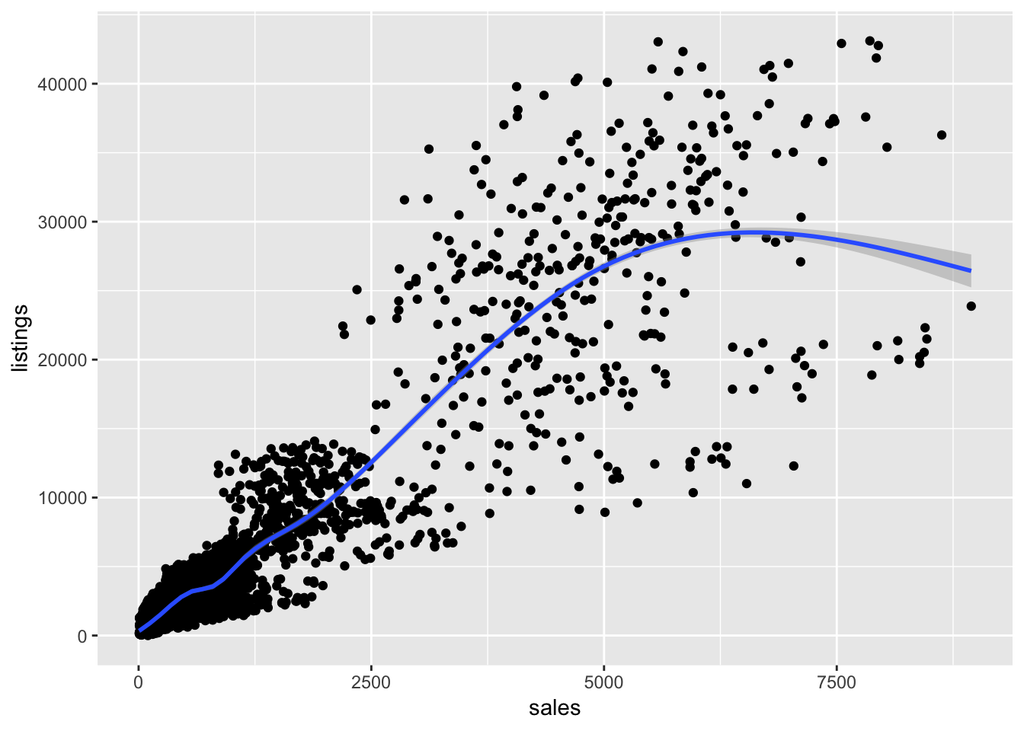

```r
ggplot(data = txhousing, mapping = aes(x = sales, y = listings)) + geom_point() + geom_smooth()
```

5. We can see the proportion of missing sales to how many houses there are, in descencing order for each city.

```r
missing_sales <- txhousing %>% group_by(city) %>% summarise(missing =(sum(is.na(sales)) / n() * 100))
arrange(missing_sales, desc(missing))
```

```
## # A tibble: 46 x 2
##    city               missing
##    <chr>                <dbl>
##  1 South Padre Island   62.0
##  2 Kerrville            55.6
##  3 Midland              40.1
##  4 Odessa               38.5
##  5 San Marcos           24.6
##  6 Laredo               19.3
##  7 Harlingen            13.4
##  8 Waco                 10.2
##  9 Texarkana             9.09
## 10 Brazoria County       7.49
## # … with 36 more rows
```

6. Cities with greater than 500 sales

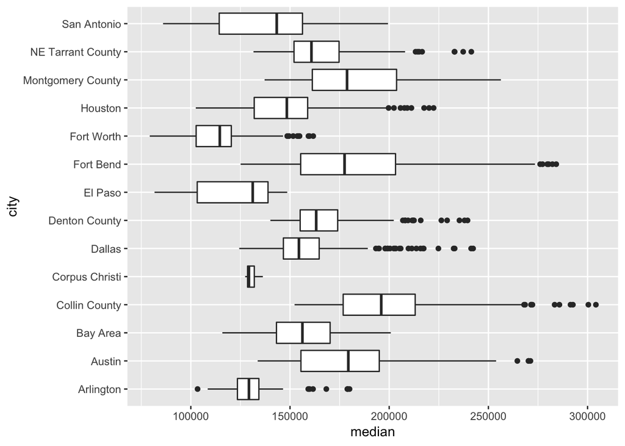

```r
greater_than_500 <- filter(txhousing, sales > 500)
ggplot(data = greater_than_500, mapping = aes(x=city, y=median)) + coord_flip() + geom_boxplot()
```

Part 1 - The medians are distributed differently.

part 2 - Corpus Christi either has very little data points, or they’re all within the same range. I would want to zoom into this specific city to see whats going on.